# IC Case 31: Summary of Data Analysis for H1 and H2

- Show All Code
- Hide All Code
- View Source

Employees Federal Credit Union (EFCU)

Author

Ron Sabilla

Published

November 12, 2026

## 1 Overview

This report covers the first two hypotheses for Case 31:

|  | Hypothesis | Variables | Test |
| --- | --- | --- | --- |
| **H1** | Members’ awareness of the regular share account will influence their opinion on how well CU’s financial services meet members’ needs. | Q13r (IV, 3 groups) → Q33 (DV) | One-way ANOVA |
| **H2** | Members will not differ in their opinion on CU’s loan rate (Q8r) and how much they agree that CU’s loan rate is lower than competitors’ (Q30). | Q8r vs. Q30 (same respondents) | Paired samples t-test |

**Why these tests?**

- **H1:** The IV (awareness) is a categorical variable with **three groups**, and the DV (Q33) is a 5-point interval scale. Comparing the means of 3+ independent groups calls for a **one-way ANOVA**. Running multiple t-tests instead would inflate the Type I error rate.
- **H2:** Both Q8r and Q30 are interval scales answered by the **same members**, so the two scores aren’t independent. A **paired samples t-test** compares each member’s two answers against each other.

```r
library(haven)
library(dplyr)
library(ggplot2)
library(knitr)

efcu <- zap_labels(read_sav("case31_efcu_4.sav"))
cat("Respondents:", nrow(efcu))
```

```
Respondents: 128
```

## 2 H1: Awareness of Regular Share Account → Services Meet Members’ Needs

**Variables**

- **Q13r (IV):** awareness of the regular share account, recoded so higher = more involvement: 1 = Unaware, 2 = Aware but have not used, 3 = Aware and have used
- **Q33 (DV):** “CU’s financial services meet the needs of members” (1 = Strongly Disagree to 5 = Strongly Agree)

```r
efcu <- efcu |>
  mutate(awareness = factor(q13_r, levels = 1:3,
                            labels = c("Unaware",
                                       "Aware, not used",
                                       "Aware & used")))
```

### 2.1 H1: Descriptive Statistics

```r
h1_desc <- efcu |>
  group_by(awareness) |>
  summarise(n = n(),
            Mean = round(mean(q33), 2),
            SD = round(sd(q33), 2),
            `% Agree (4–5)` = round(100 * mean(q33 >= 4), 1),
            `% Disagree (1–2)` = round(100 * mean(q33 <= 2), 1))
kable(h1_desc)
```

Table 1: Q33 (services meet members’ needs) by awareness of the regular share account

| awareness | n | Mean | SD | % Agree (4–5) | % Disagree (1–2) |
| --- | --- | --- | --- | --- | --- |
| Unaware | 83 | 3.63 | 0.66 | 62.7 | 4.8 |
| Aware, not used | 32 | 3.72 | 0.63 | 62.5 | 0.0 |
| Aware & used | 13 | 3.08 | 0.76 | 30.8 | 23.1 |

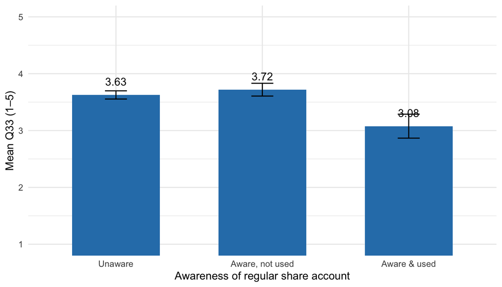

Figure 1: Mean agreement that CU’s services meet members’ needs, by awareness group (error bars = ±1 SE)

```r
efcu |>
  group_by(awareness) |>
  summarise(mean = mean(q33), se = sd(q33) / sqrt(n())) |>
  ggplot(aes(x = awareness, y = mean)) +
  geom_col(fill = "#2c7fb8", width = 0.6) +
  geom_errorbar(aes(ymin = mean - se, ymax = mean + se), width = 0.15) +
  geom_text(aes(label = round(mean, 2)), vjust = -1.2) +
  coord_cartesian(ylim = c(1, 5)) +
  labs(x = "Awareness of regular share account",
       y = "Mean Q33 (1–5)") +
  theme_minimal()
```

Looking at Table 1 and Figure 1 first:

- Most of the sample (83 of 128) says they’re **unaware** of the regular share account. Only 13 members say they’ve actually used it, so that group is small.
- Members who are **unaware** (3.63) or **aware but haven’t used it** (3.72) both lean slightly toward agreeing that CU meets members’ needs. More than half of each group agrees.
- Members who have **actually used** the account are noticeably less positive (3.08). Only about 31% of them agree, and 23% disagree, the highest disagreement of any group.

My read: the people with the most hands-on experience with CU’s basic account are the least convinced that CU’s services meet their needs.

### 2.2 H1: One-way ANOVA

```r
# Homogeneity of variance
bartlett.test(q33 ~ awareness, data = efcu)
```

```
    Bartlett test of homogeneity of variances

data:  q33 by awareness
Bartlett's K-squared = 0.60535, df = 2, p-value = 0.7388
```

```r
h1_aov <- aov(q33 ~ awareness, data = efcu)
summary(h1_aov)
```

```
             Df Sum Sq Mean Sq F value Pr(>F)
awareness     2   4.06  2.0307   4.631 0.0115 *
Residuals   125  54.81  0.4385
---
Signif. codes:  0 '***' 0.001 '**' 0.01 '*' 0.05 '.' 0.1 ' ' 1
```

```r
# Effect size (eta squared)
ss <- summary(h1_aov)[[1]][["Sum Sq"]]
cat("Eta squared =", round(ss[1] / sum(ss), 3))
```

```
Eta squared = 0.069
```

```r
TukeyHSD(h1_aov)
```

```
  Tukey multiple comparisons of means
    95% family-wise confidence level

Fit: aov(formula = q33 ~ awareness, data = efcu)

$awareness
                                    diff        lwr         upr     p adj
Aware, not used-Unaware       0.09224398 -0.2345927  0.41908065 0.7816413
Aware & used-Unaware         -0.54958295 -1.0180950 -0.08107087 0.0170339
Aware & used-Aware, not used -0.64182692 -1.1584282 -0.12522563 0.0106252
```

```r
# Robustness check given unequal group sizes
oneway.test(q33 ~ awareness, data = efcu)
```

```
    One-way analysis of means (not assuming equal variances)

data:  q33 and awareness
F = 3.6171, num df = 2.000, denom df = 29.729, p-value = 0.03926
```

The variances are similar across groups (Bartlett’s K² = 0.61, p = .74), so a standard ANOVA is appropriate.

### 2.3 H1: Insight

**H1 is supported. Awareness of the regular share account does influence how members feel about CU meeting their needs, but not in the direction you’d probably expect.** Members who have actually used the account rate CU lower on meeting their needs (M = 3.08) than both members who are unaware of it (M = 3.63) and members who know about it but haven’t used it (M = 3.72) (*F*(2, 125) = 4.63, *p* = .012, η² = .07). The Tukey post-hoc tests confirm the “used” group is the one that differs (vs. unaware: *p* = .017; vs. aware-not-used: *p* = .011), while unaware and aware-not-used members aren’t different from each other (*p* = .78). The result holds even with Welch’s correction for the unequal group sizes (*p* = .039).

**What this means for EFCU:** Simply making members aware of the share account doesn’t hurt or help. But the experience of *using* it seems to leave members feeling their needs aren’t fully met. That points to a product or service issue with the account itself (rates, features, convenience) rather than a communication problem. EFCU should talk to current users about what’s missing before putting more effort into promoting it.

**Caveat:** Only 13 members are in the “aware and used” group, so this finding should be confirmed with a larger sample. It’s also unusual that 65% of credit union members say they’re unaware of the regular share account, since it’s usually a basic part of membership. Some members may have misread the question.

## 3 H2: Opinion on CU’s Loan Rate (Q8r) vs. Agreement That CU’s Rate Is Lower (Q30)

**Variables**

- **Q8r:** “Opinion about rates charged on borrowed funds,” recoded to 1 = Very Low to 5 = Very High. “No opinion” (21 members) is set to missing.
- **Q30:** “CU loan rates lower than others” (1 = Strongly Disagree to 5 = Strongly Agree)

```r
h2 <- efcu |>
  select(Q8_r, q30) |>
  filter(!is.na(Q8_r), !is.na(q30))
cat("Members with both answers:", nrow(h2))
```

```
Members with both answers: 107
```

### 3.1 H2: Descriptive Statistics

```r
h2_desc <- data.frame(
  Item = c("Q8r: Opinion on CU loan rate (1 = very low, 5 = very high)",
           "Q30: CU loan rates lower than others (1 = SD, 5 = SA)"),
  Mean = round(c(mean(h2$Q8_r), mean(h2$q30)), 2),
  SD   = round(c(sd(h2$Q8_r), sd(h2$q30)), 2),
  `% at midpoint (3)` = round(100 * c(mean(h2$Q8_r == 3), mean(h2$q30 == 3)), 1),
  check.names = FALSE
)
kable(h2_desc)
```

Table 2: Descriptive statistics for Q8r and Q30 (paired sample, n = 107)

| Item | Mean | SD | % at midpoint (3) |
| --- | --- | --- | --- |
| Q8r: Opinion on CU loan rate (1 = very low, 5 = very high) | 3.14 | 0.76 | 55.1 |
| Q30: CU loan rates lower than others (1 = SD, 5 = SA) | 3.06 | 0.92 | 41.1 |

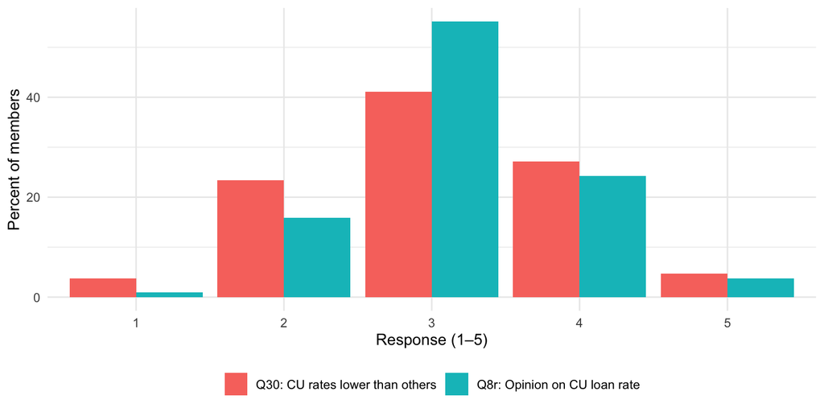

Figure 2: Response distributions for Q8r and Q30 (n = 107)

```r
h2 |>
  tidyr::pivot_longer(everything(), names_to = "item", values_to = "score") |>
  mutate(item = recode(item,
                       Q8_r = "Q8r: Opinion on CU loan rate",
                       q30  = "Q30: CU rates lower than others")) |>
  count(item, score) |>
  group_by(item) |>
  mutate(pct = 100 * n / sum(n)) |>
  ggplot(aes(x = factor(score), y = pct, fill = item)) +
  geom_col(position = "dodge") +
  labs(x = "Response (1–5)", y = "Percent of members", fill = NULL) +
  theme_minimal() +
  theme(legend.position = "bottom")
```

From Table 2 and Figure 2:

- Both items sit right at the middle of the scale. Q8r averages 3.14 (“average” rate) and Q30 averages 3.06 (“uncertain”).
- More than half of members picked the midpoint on Q8r (55%), and about 41% did on Q30. Members don’t have a strong opinion on CU’s loan rates either way.
- Another 21 members (16% of the sample) chose “No opinion” on Q8. That’s another sign many members don’t really know how CU’s loan rates compare.

### 3.2 H2: Paired Samples t-test

```r
h2_t <- t.test(h2$Q8_r, h2$q30, paired = TRUE)
h2_t
```

```
    Paired t-test

data:  h2$Q8_r and h2$q30
t = 0.60088, df = 106, p-value = 0.5492
alternative hypothesis: true mean difference is not equal to 0
95 percent confidence interval:
 -0.1934139  0.3616382
sample estimates:
mean difference
     0.08411215
```

```r
# Effect size (Cohen's d for paired samples)
diffs <- h2$Q8_r - h2$q30
cat("Cohen's d =", round(mean(diffs) / sd(diffs), 3))
```

```
Cohen's d = 0.058
```

### 3.3 H2: Insight

**H2 is supported. Members’ opinion of CU’s loan rate and their agreement that CU’s rate is lower than competitors’ are essentially the same, and both are neutral** (Q8r M = 3.14 vs. Q30 M = 3.06; *t*(106) = 0.60, *p* = .55, *d* = 0.06). The average difference is less than a tenth of a scale point.

**What this means for EFCU:** The real story isn’t the “no difference” result. It’s that members are **unsure about CU’s loan rates in general**. Most picked “average” or “uncertain,” and 1 in 6 had no opinion at all. For a credit union, competitive loan rates should be a key selling point, but members aren’t seeing it. EFCU has an opportunity to clearly communicate how its loan rates compare to banks and other lenders (for example, side-by-side rate comparisons in statements, on the website, or at the branch).

**A note on scale direction:** The two items point in opposite directions. A *high* Q8r means members think the rate is high (unfavorable), while a *high* Q30 means they agree the rate is lower (favorable). The negative correlation between them (*r* = –.49) confirms this. I ran the test as specified in the data analysis table. But if Q8r is flipped so both items point the same way (higher = more favorable view of rates), the difference becomes small but significant (*t*(106) = –2.35, *p* = .02), with members slightly *less* favorable when rating the rate directly (M = 2.86) than when comparing it to competitors (M = 3.06). Either way, both scores land near the neutral midpoint, so the overall takeaway stays the same: members don’t see CU’s loan rates as a clear advantage.

```r
cor(h2$Q8_r, h2$q30)
```

```
[1] -0.4850371
```

**Sensitivity check: Q8r reversed to match Q30’s direction**

```r
t.test(6 - h2$Q8_r, h2$q30, paired = TRUE)
```

```
    Paired t-test

data:  6 - h2$Q8_r and h2$q30
t = -2.3534, df = 106, p-value = 0.02045
alternative hypothesis: true mean difference is not equal to 0
95 percent confidence interval:
 -0.36159829 -0.03092508
sample estimates:
mean difference
     -0.1962617
```

## 4 Summary of Findings

| Hypothesis | Result | Key insight |
| --- | --- | --- |
| **H1** | Supported | Members who have *used* the regular share account feel CU meets their needs less (3.08) than unaware (3.63) or aware-but-not-using members (3.72). The account experience itself may be falling short. |
| **H2** | Supported | Members rate CU’s loan rate and its rate vs. competitors about the same, and both are neutral (~3.1). Members don’t see CU’s loan rates as a clear advantage, which is a communication opportunity. |

## 5 Appendix

- **GitHub Repo:** https://github.com/rsabilla/REPO-NAME
- **GitHub Pages:** https://rsabilla.github.io/REPO-NAME/